# SADM_Lab1

Question 1:

```r
set.seed(0)
n = 6000; m = 201
vect = rnorm(n*m)
m = matrix(vect,nrow = n, ncol = m)
d = as.data.frame(m)
```

Question 2:

Multiple linear regression model: Using the 200 predictors,
$$\forall i \in [1,6000] \space x_{0 i} = \sum_{j=1}^{200}\beta_{j} x_{ji} + \beta_0 + \epsilon_i$$

True regression model: (?? A VERIFIER)
$$\space x_{0} = \sum_{x=1}^{1206000} \beta_{i} x_{i} + \beta_0 + \epsilon_0$$

Question 3 :

```r
reg<-lm(d$V1 ~ ., d)
summary(reg)$coefficients
```

```
##                  Estimate Std. Error       t value    Pr(>|t|)
## (Intercept)  0.0120882385 0.01312444  0.9210478100 0.357063780
## V2          -0.0227566856 0.01304871 -1.7439800780 0.081215550
## V3           0.0052197438 0.01325556  0.3937776303 0.693759699
## V4           0.0092170213 0.01307307  0.7050387814 0.480814418
## V5          -0.0042651231 0.01294097 -0.3295830649 0.741726924
## V6           0.0168374351 0.01310540  1.2847705505 0.198923792
## V7          -0.0040378483 0.01293554 -0.3121513911 0.754936695
## V8           0.0113733075 0.01312466  0.8665604205 0.386218760
## V9          -0.0141704305 0.01334876 -1.0615543661 0.288482247
## V10         -0.0031861610 0.01321791 -0.2410487885 0.809525825
## V11         -0.0195158877 0.01310978 -1.4886506841 0.136633755
## V12         -0.0099643484 0.01301047 -0.7658717215 0.443783805
## V13         -0.0153082242 0.01301120 -1.1765422912 0.239426536
## V14          0.0041603486 0.01317988  0.3156589755 0.752272728
## V15          0.0063300971 0.01298919  0.4873357502 0.626038838
## V16          0.0110562072 0.01321219  0.8368188650 0.402728874
## V17          0.0026747687 0.01323038  0.2021686701 0.839791957
## V18         -0.0076840075 0.01313366 -0.5850620853 0.558528735
## V19         -0.0047094906 0.01314724 -0.3582114182 0.720198141
## V20          0.0251676238 0.01328903  1.8938648618 0.058292672
## V21         -0.0096750414 0.01317860 -0.7341477582 0.462888371
## V22         -0.0015903163 0.01311421 -0.1212666805 0.903484012
## V23          0.0036234799 0.01311259  0.2763359915 0.782299862
## V24         -0.0024828986 0.01317222 -0.1884950821 0.850495166
## V25         -0.0146304838 0.01295560 -1.1292784336 0.258827107
## V26         -0.0105889107 0.01315678 -0.8048251855 0.420953561
## V27          0.0181578648 0.01321335  1.3742063217 0.169430746
## V28         -0.0007312358 0.01296261 -0.0564111598 0.955016210
## V29          0.0055965253 0.01325565  0.4221993067 0.672895199
## V30         -0.0029993716 0.01317798 -0.2276048394 0.819961481
## V31          0.0000076605 0.01315456  0.0005823456 0.999535375
## V32          0.0038732892 0.01324249  0.2924895126 0.769922841
## V33          0.0223883155 0.01307320  1.7125353636 0.086851512
## V34          0.0093634096 0.01318556  0.7101262950 0.477654376
## V35          0.0130727360 0.01316206  0.9932137272 0.320647250
## V36         -0.0152411664 0.01307021 -1.1660996872 0.243622099
## V37          0.0045942492 0.01328837  0.3457346109 0.729554712
## V38         -0.0156383196 0.01301038 -1.2019881042 0.229417218
## V39          0.0057812899 0.01335224  0.4329826843 0.665043452
```

[output cut: 147 more lines]

```
## V187         0.0093502265 0.01314427  0.7113538069 0.476893628
## V188         0.0138620411 0.01321826  1.0487041702 0.294357998
## V189         0.0066285946 0.01302923  0.5087478462 0.610948335
## V190         0.0068781961 0.01322455  0.5201081355 0.603008062
## V191        -0.0145356244 0.01303855 -1.1148186713 0.264974332
## V192        -0.0067780713 0.01305506 -0.5191910406 0.603647340
## V193         0.0068333045 0.01317270  0.5187474679 0.603956649
## V194         0.0170133860 0.01298630  1.3101023308 0.190213112
## V195         0.0013724772 0.01335845  0.1027422667 0.918171080
## V196        -0.0202953406 0.01318255 -1.5395611497 0.123721922
## V197         0.0058993414 0.01304024  0.4523950938 0.651001303
## V198         0.0255165190 0.01339056  1.9055605032 0.056756655
## V199         0.0148002650 0.01302409  1.1363757009 0.255846319
## V200         0.0271136115 0.01332359  2.0350075116 0.041895505
## V201        -0.0218151201 0.01296362 -1.6827952886 0.092468559
```

```r
summary(reg)$coefficients[summary(reg)$coefficients[,4]<=0.05,] #?? A VERIFIER
```

```
##         Estimate Std. Error   t value    Pr(>|t|)
## V94   0.02995744 0.01313331  2.281027 0.022582923
## V125 -0.02890440 0.01305089 -2.214746 0.026816252
## V136 -0.02670964 0.01303501 -2.049069 0.040500240
## V141 -0.02743157 0.01327626 -2.066212 0.038852768
## V148  0.03697463 0.01291908  2.862018 0.004224608
## V169  0.03011634 0.01302202  2.312724 0.020772670
## V172 -0.04079252 0.01307226 -3.120541 0.001814059
## V177 -0.03900412 0.01309805 -2.977858 0.002914717
## V200  0.02711361 0.01332359  2.035008 0.041895505
```

Question 4:

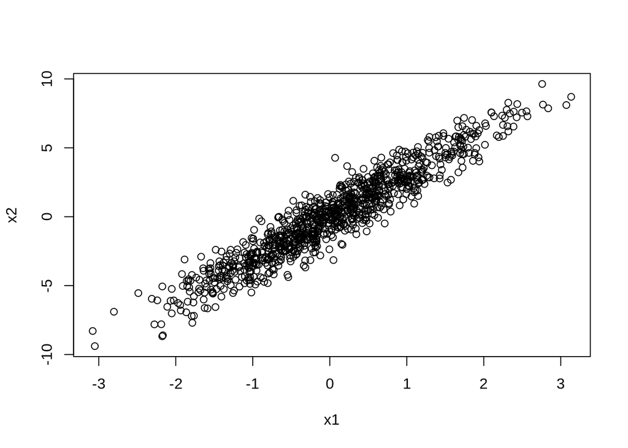

```r
n = 1000
eps1 = rnorm(n)
eps2 = rnorm(n)
eps3 = rnorm(n)
x1 = eps1
x2 = 3*x1 + eps2
y = x1 + x2 + 2 + eps3
plot(x1,x2)
```

$X_2$ and $X_1$ are clearly correlated. The plot resembles that of the function $y=3x$ with a fluctuation around it due to $\epsilon_2$.

Question 5:

```r
reg1 <- lm(y~x1)
summary(reg1)$coefficients
```

```
##             Estimate Std. Error  t value      Pr(>|t|)
## (Intercept) 2.010647 0.04371452 45.99495 8.288236e-249
## x1          4.052616 0.04350924 93.14382  0.000000e+00
```

```r
beta1 = summary(reg1)$coefficients[2,1]; beta1
```

```
## [1] 4.052616
```

```r
beta0 = summary(reg1)$coefficients[1,1]; beta0
```

```
## [1] 2.010647
```

```r
sigmat1 = summary(reg1)$coefficients[1,2]; sigmat1 #?? (A VERIFIER)
```

```
## [1] 0.04371452
```

```r
reg2 <- lm(y~x2)
summary(reg2)$coefficients
```

```
##             Estimate Std. Error   t value Pr(>|t|)
## (Intercept) 2.026159 0.03257927  62.19166        0
## x2          1.297341 0.01012583 128.12197        0
```

```r
beta2 = summary(reg2)$coefficients[2,1]; beta2
```

```
## [1] 1.297341
```

```r
sigmat2 = summary(reg2)$coefficients[1,2]; sigmat2
```

```
## [1] 0.03257927
```

The coefficients computed are quite close to the real values, except maybe for $\beta_2$, because of the presence of two random variables in the simulated values.

```r
set.seed(3)
n = 10
eps1 = rnorm(n)
eps2 = rnorm(n)
eps3 = rnorm(n)
x1 = eps1
x2 = 3*x1 + eps2
y = x1 + x2 + 2 + eps3
reg1 <- lm(y~x1)
beta1 = summary(reg1)$coefficients[2,1]; beta1
```

```
## [1] 4.086136
```

```r
beta0 = summary(reg1)$coefficients[1,1]; beta0
```

```
## [1] 1.373268
```

```r
sigmat1 = summary(reg1)$coefficients[1,2]; sigmat1
```

```
## [1] 0.3258239
```

```r
reg2 <- lm(y~x2)
beta2 = summary(reg2)$coefficients[2,1]; beta2
```

```
## [1] 1.423877
```

```r
sigmat2 = summary(reg2)$coefficients[1,2]; sigmat2
```

```
## [1] 0.3292444
```

By lowering the value of $n$, the computed values are less accurate, the variances $\tilde{\epsilon}_j$ are also bigger which indicates that the precision of the regression has decreased significantly.

```r
reg3 = lm(y~x1+x2)
#summary(reg3)
beta2 = summary(reg3)$coefficients[3,1]; beta2
```

```
## [1] 0.7336134
```

```r
beta1 = summary(reg3)$coefficients[2,1]; beta1
```

```
## [1] 2.062824
```

```r
beta0 = summary(reg3)$coefficients[1,1]; beta0
```

```
## [1] 1.581241
```

```r
sigma = summary(reg3)$coefficients[1,2]; sigma
```

```
## [1] 0.3233549
```

PART 2 :

1 -

```r
prostateCancer<-read.table("./prostate.data",header=T);
attach(prostateCancer)
```

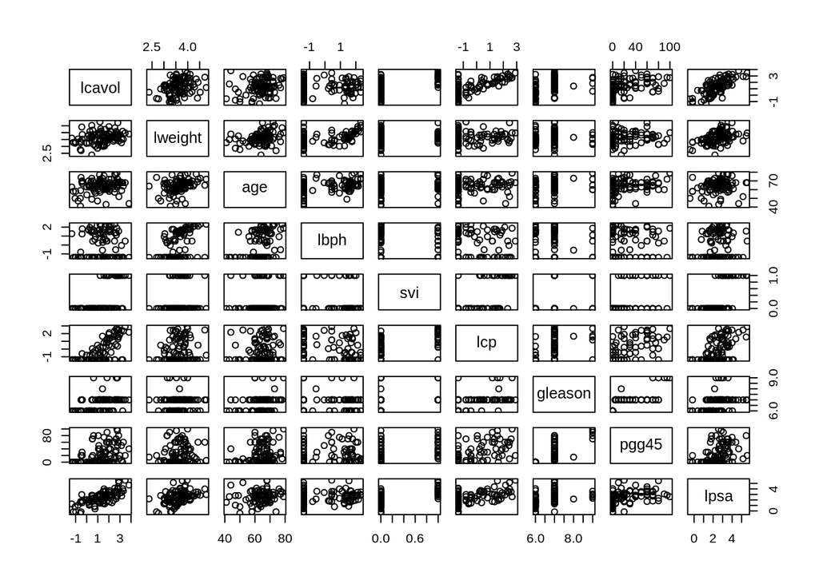

```r
pro <- prostateCancer[1:9]
pairs(pro)
```

There is an apparently strong correlation between lcavol and : svi, lcp and lpsa.

2 -

```r
pro$gleason<-factor(pro$gleason)
pro$svi<-factor(pro$svi)

reg <- lm(pro$lcavol ~., pro)
summary(reg)
```

```
##
## Call:
## lm(formula = pro$lcavol ~ ., data = pro)
##
## Residuals:
##      Min       1Q   Median       3Q      Max
## -1.91436 -0.48444 -0.02664  0.54915  1.80062
##
## Coefficients:
##              Estimate Std. Error t value Pr(>|t|)
## (Intercept) -1.406654   0.874455  -1.609   0.1114
## lweight     -0.011246   0.211453  -0.053   0.9577
## age          0.024782   0.011241   2.205   0.0301 *
## lbph        -0.104200   0.058209  -1.790   0.0770 .
## svi1        -0.220419   0.256351  -0.860   0.3923
## lcp          0.402760   0.085074   4.734 8.58e-06 ***
## gleason7     0.311676   0.215268   1.448   0.1513
## gleason8    -0.710588   0.758827  -0.936   0.3517
## gleason9     0.790135   0.487510   1.621   0.1087
## pgg45       -0.009444   0.004540  -2.080   0.0405 *
## lpsa         0.549573   0.090093   6.100 2.94e-08 ***
## ---
## Signif. codes:  0 '***' 0.001 '**' 0.01 '*' 0.05 '.' 0.1 ' ' 1
##
## Residual standard error: 0.6973 on 86 degrees of freedom
## Multiple R-squared:  0.6865, Adjusted R-squared:   0.65
## F-statistic: 18.83 on 10 and 86 DF,  p-value: < 2.2e-16
```

- We notice the presence of gleason7, 8 and 9 instead of gleason. Each one of these variables represents a level of the variable we made quantitative (using the command factor()). Basically, instead of performing a regression based on the 4 possible values of gleason, we seperate the variable gleason into 3 variables, each one representing a simple “YES” or “NO” if the variable is equal to the corresponding level (we don’t need a fourth one, since its value can be deduced from the 3 others). The same thing applies for the variable svi, with 2 levels, we find ourselves with one variable in the linear regression, with the same meaning as described before.
- There is a strong correlation between lcavol and : lcp and lpsa with a p-value inferior to $10^{-5}$, and a weak correlation between lcavol and pgg45 with a p-value inferior to $0.1$.

```r
confint(reg)
```

```
##                    2.5 %        97.5 %
## (Intercept) -3.145013212  0.3317051396
## lweight     -0.431599858  0.4091074596
## age          0.002435876  0.0471289533
## lbph        -0.219914296  0.0115152113
## svi1        -0.730029034  0.2891903039
## lcp          0.233638987  0.5718802443
## gleason7    -0.116263131  0.7396155044
## gleason8    -2.219087210  0.7979107787
## gleason9    -0.179003633  1.7592727371
## pgg45       -0.018468522 -0.0004191483
## lpsa         0.370473639  0.7286725619
```

```r
reg_lpsa <- lm(pro$lcavol ~lpsa)
summary(reg_lpsa)$coefficients
```

```
##               Estimate Std. Error   t value     Pr(>|t|)
## (Intercept) -0.5085796 0.19419304 -2.618938 1.026692e-02
## lpsa         0.7499189 0.07109369 10.548319 1.118609e-17
```

```r
confint(reg_lpsa)
```

```
##                  2.5 %     97.5 %
## (Intercept) -0.8941016 -0.1230577
## lpsa         0.6087801  0.8910577
```

lpsa is a very strong predictor of lcavol.

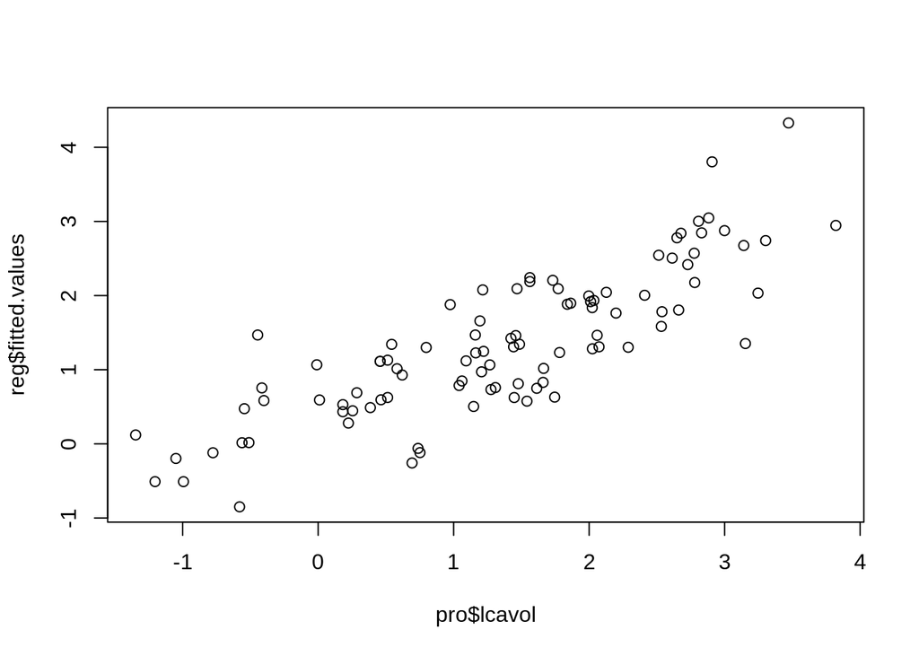

```r
plot(pro$lcavol, reg$fitted.values)
```

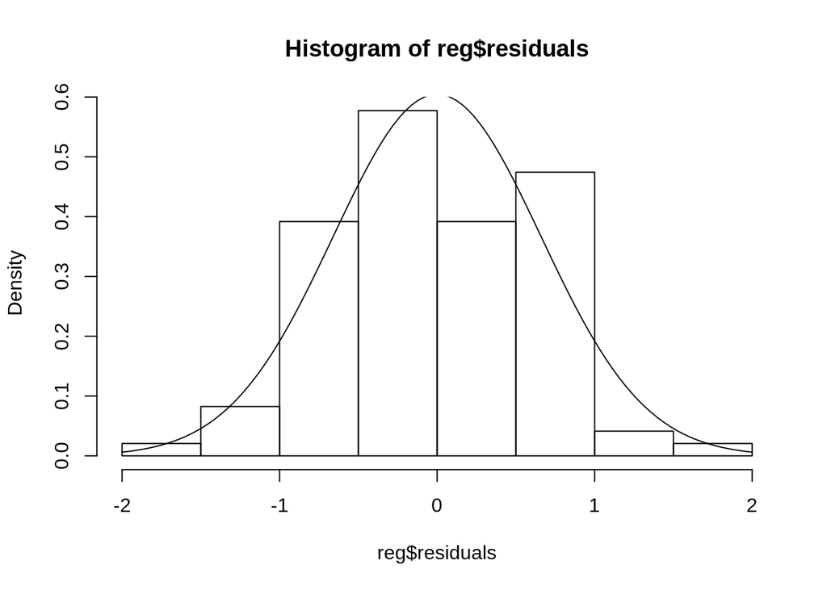

```r
hist(reg$residuals, prob=TRUE)
norm <- function(x){
  return (dnorm(x, sd = sd(reg$residuals)))
}
par(new=TRUE)
curve(norm(x), add=TRUE)
```

Yes, we can admit that the residuals are normally distributed.

The residual sum of squares :

```r
sum(reg$residuals^2)
```

```
## [1] 41.81407
```

```r
reg_f = lm(pro$lcavol ~ pro$lweight + pro$age + pro$lbph + pro$svi + pro$gleason + pro$pgg45)
summary(reg_f)
```

```
##
## Call:
## lm(formula = pro$lcavol ~ pro$lweight + pro$age + pro$lbph +
##     pro$svi + pro$gleason + pro$pgg45)
##
## Residuals:
##      Min       1Q   Median       3Q      Max
## -1.84488 -0.48256 -0.01752  0.58918  2.21990
##
## Coefficients:
##                Estimate Std. Error t value Pr(>|t|)
## (Intercept)  -1.9717103  1.1590310  -1.701 0.092442 .
## pro$lweight   0.5849583  0.2591548   2.257 0.026472 *
## pro$age       0.0072858  0.0146727   0.497 0.620739
## pro$lbph     -0.0746433  0.0771750  -0.967 0.336097
## pro$svi1      1.0245817  0.2714729   3.774 0.000291 ***
## pro$gleason7  0.8007406  0.2744312   2.918 0.004473 **
## pro$gleason8  0.6868720  0.9601171   0.715 0.476253
## pro$gleason9  1.1726480  0.6444380   1.820 0.072214 .
## pro$pgg45    -0.0004312  0.0056372  -0.076 0.939203
## ---
## Signif. codes:  0 '***' 0.001 '**' 0.01 '*' 0.05 '.' 0.1 ' ' 1
##
## Residual standard error: 0.9272 on 88 degrees of freedom
## Multiple R-squared:  0.4327, Adjusted R-squared:  0.3811
## F-statistic:  8.39 on 8 and 88 DF,  p-value: 2.11e-08
```

By plotting the fitted values against the real values :

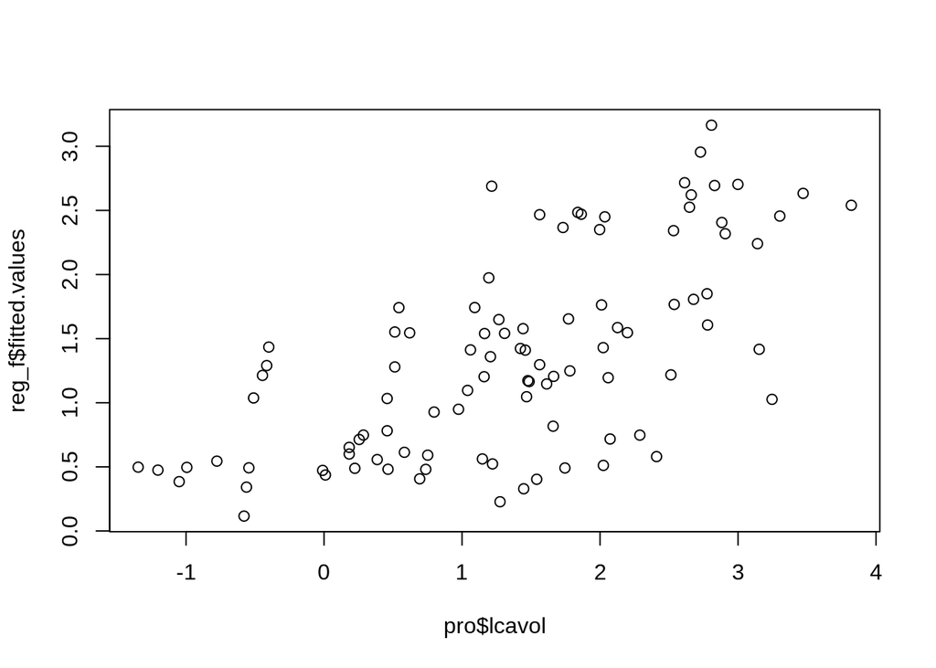

```r
plot(pro$lcavol, reg_f$fitted.values)
```

By removing the best predictors, the model becomes quite inaccurate in comparison to the previous one, even if the p-value of svi1 is very low, that’s because that variable is the best predictor between all the predictors available, and is not an indicator of the validity of the model in itself.

3 -

```r
aov_svi<-aov(pro$lcavol~pro$svi, pro); summary(aov_svi)
```

```
##             Df Sum Sq Mean Sq F value   Pr(>F)
## pro$svi      1  38.72   38.72   38.87 1.24e-08 ***
## Residuals   95  94.64    1.00
## ---
## Signif. codes:  0 '***' 0.001 '**' 0.01 '*' 0.05 '.' 0.1 ' ' 1
```

```r
aov_gleason<-aov(pro$lcavol~pro$gleason, pro); summary(aov_gleason)
```

```
##             Df Sum Sq Mean Sq F value  Pr(>F)
## pro$gleason  3  34.48  11.493   10.81 3.7e-06 ***
## Residuals   93  98.88   1.063
## ---
## Signif. codes:  0 '***' 0.001 '**' 0.01 '*' 0.05 '.' 0.1 ' ' 1
```

```r
avo2 <-aov(pro$lcavol~pro$gleason*pro$svi, pro); summary(avo2)
```

```
##                     Df Sum Sq Mean Sq F value   Pr(>F)
## pro$gleason          3  34.48  11.493  13.086 3.53e-07 ***
## pro$svi              1  17.94  17.937  20.425 1.86e-05 ***
## pro$gleason:pro$svi  1   1.03   1.026   1.168    0.283
## Residuals           91  79.92   0.878
## ---
## Signif. codes:  0 '***' 0.001 '**' 0.01 '*' 0.05 '.' 0.1 ' ' 1
```

By performing the one way ANOVA on the two qualitative variables, we can deduce that they’re statistically very significant to predict lcavol. The two way ANOVA tells us that the interaction between the two variables, however, is not statistically significant at all (p-value too high).

4 -

```r
reg1<-lm(lcavol ~ 1, data=pro)
reg2<-lm(lcavol ~ .,data=pro[,c(1,4,9)])
reg3<-lm(lcavol ~ ., data=pro[,c(1,2,9)])
sum(reg1$residuals^2)
```

```
## [1] 133.359
```

```r
sum(reg2$residuals^2)
```

```
## [1] 59.90979
```

```r
sum(reg3$residuals^2)
```

```
## [1] 61.18712
```

```r
res_min = 1000
cb = combn(9,2)
for (i in 1:dim(cb)[2]){
  c<-cb[,i]
  reg<-lm(lcavol ~ .,data=pro[,c])
  if(sum(reg$residuals^2)<res_min){
    res_min = sum(reg$residuals^2)
    min = c
  }
}
cat(res_min); cat("\n"); cat(names(pro)[min]); cat("\n")
```

```
## 47.2781
```

```
## lcp lpsa
```

The best couple of predictors is (lcp, lpsa), just as deduced in former questions.

```r
ress = c()

#k=0
reg<-lm(lcavol ~ 1, data=pro);
ress = c(ress, sum(reg$residuals^2))
cat("k = 0", "\n");
```

```
## k = 0
```

```r
cat(sum(reg$residuals^2)); cat("\n");
```

```
## 133.359
```

```r
cat("--\n\n")
#k=1
for (k in 2:9){
  res_min = 1000
  reg<-lm(lcavol ~ pro[,k])
  if(sum(reg$residuals^2)<res_min){
    res_min = sum(reg$residuals^2)
    min = k
  }
}
ress = c(ress, sum(reg$residuals^2))
cat("k = 1", "\n");
```

```
## k = 1
```

```r
cat(res_min); cat("\n");
```

```
## 61.42091
```

```r
cat(names(pro)[min]); cat("\n\n")
```

```
## lpsa
```

```r
#k from 2 to 8
for(k in 2:8){
  res_min = 1000
  cb = combn(9,k)
  for (i in 1:dim(cb)[2]){
    c<-cb[,i]
    reg<-lm(lcavol ~ .,data=pro[,c])
    if(sum(reg$residuals^2)<res_min){
      res_min = sum(reg$residuals^2)
      min = c
    }
  }
  ress = c(ress, sum(reg$residuals^2))
  cat("k = ", k, "\n");
  cat(res_min); cat("\n");
  cat(names(pro)[min]); cat("\n\n")
}
```

```
## k =  2
## 47.2781
## lcp lpsa
##
## k =  3
## 46.23783
## age lcp lpsa
##
## k =  4
## 44.87841
## age lbph lcp lpsa
##
## k =  5
## 43.68997
## age lcp gleason pgg45 lpsa
##
## k =  6
## 42.17393
## age lbph lcp gleason pgg45 lpsa
##
## k =  7
## 41.81544
## age lbph svi lcp gleason pgg45 lpsa
##
## k =  8
## 41.81407
## lweight age lbph svi lcp gleason pgg45 lpsa
```

N.B : the set of best $k$ predictors is not necessarily a subset of the set of the best $k'$ predictors, such that $k<k'$. The example $k=4$ and $k'=5$ illustrates this point.

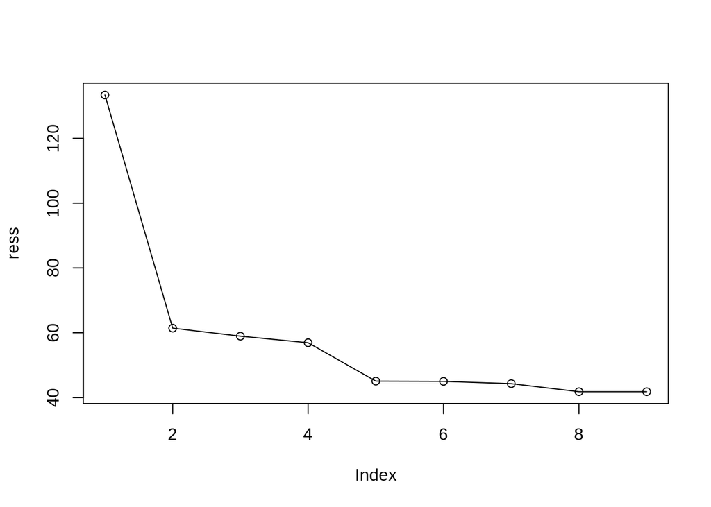

```r
plot(ress)
par(new=TRUE)
lines(ress)
```

The residual sum of squares is decreasing, which is completely predictable : the more predictors we have, the more we know about the data and therefore the fitted values get closer to the real values.

5 -

A reasonable model would be to predict lcavol basek on 6 predictors : age lbph lcp gleason pgg45 lpsa. Further predictors can be added to decrease the residual sum of squares, but not considerably.